# NBA Tanking Analysis

Rohan Dixit

May 16, 2019

## Tanking in the NBA

What is tanking?

Tanking occurs when teams that are not going to make the playoffs intentionally start trying to lose so that they have a higher probability of getting better draft picks. In the NBA, teams with the worst record have the highest likelihood of receiving the first draft pick, which means they would be able to draft the best players from college. This would help a team in the rebuilding phase. A summary of the NBA Draft Lottery can be found here: https://www.nba.com/nba-draft-lottery-explainer

The NBA has been attempting to curb tanking by changing rules that may provide benefit to lower performing teams. Typically, teams with lower records earn a higher draft pick. Therefore, the NBA instituted a lottery based system that does not make it deterministic that the lowest standing team in the NBA receives the first (best) pick in the NBA draft: https://www.si.com/nba/2019/05/15/nba-draft-lottery-lebron-james-anthony-davis-lakers-pelicans-tanking-not-dead

In order to tank and lose, teams sometimes choose to trade away their good players, play their younger/worse players more often to get them more experience. In recent years, teams have openly acknowledged tanking, such as the Dallas Mavericks in 2018 (https://twitter.com/ESPNNBA/status/965979545856806914). This past year tanking has been an even bigger point of discussion as several teams, most notably the New York Knicks, have been losing with the goal of getting the first pick and the top player in the draft, Zion Williamson: https://www.youtube.com/watch?v=zouIqKN8rZA.

## Project Motivation

Because tanking has become such a common point of discussion over the past year, we thought it would be interesting to attempt to quantify tanking in the NBA to determine if teams were making a deliberate attempt to lose. This information would be especially important to know for the NBA to decide whether or not they should change rules or fine teams for tanking during the season. We decided to use not this season’s but the previous season (2017-2018) data since the current season is ongoing and the previous year’s data is more complete. \

In order to do so, we decided to look at primarily two variables: how strong was a team’s lineup and their winning percentage throughout the season. We hypothesize that teams with a low winning percentage will have a declining strength in their team lineup as they try to tank. \

## Player Ratings

To measure overall player rating, we decided to use the video game NBA 2K18’s player ratings. NBA 2K18 is highly respected for the ratings that it reveals each year with players obsessed about how the game judges their gameplay. More information about the NBA 2K rating system: https://www.complex.com/sports/2017/10/how-nba-2k-determines-player-rankings

We downloaded ratings for every player in the game from this link: https://www.dropbox.com/s/js2hqcd152mq4kh/NBA%202k18%20All%20Players%20Master.xls?dl=0. This document also contains player ratings for historical teams so to focus our analysis on this year, we filtered by year 2017/2018.

One limitation of this document is that it does not contain free agents’ ratings who do not begin on a team but can be signed by a team. We will explain how we dealt with this in a later section.

```r
library(tidyverse)
full_ratings <- read.csv("C:/Users/Rohan/Documents/Spring 2019/CMSC320/Final Project/NBA 2K18 Ratings.csv")
ratings2018 <- full_ratings %>%
  select(Player, Year, Rating) %>%
  filter(Year == "2017/2018") %>%
  arrange(Player)
head(ratings2018)
```

```
##           Player      Year Rating
## 1   A.J. Hammons 2017/2018     68
## 2   Aaron Brooks 2017/2018     72
## 3   Aaron Gordon 2017/2018     82
## 4 Aaron Harrison 2017/2018     65
## 5  Aaron Jackson 2017/2018     65
## 6    Abdel Nader 2017/2018     67
```

## Enhanced Box Score Data

The next step for our project was to determine how many minutes each player played in every game of the NBA season to determine a team’s lineup for a given game. We used the Kaggle dataset https://www.kaggle.com/pablote/nba-enhanced-stats to obtain this information. Since we were focusing on 2017-2018, we downloaded “2017-18_playerBoxScore.csv” and filtered for the necessary information.

```r
box_scores <- read.csv("C:/Users/Rohan/Documents/Spring 2019/CMSC320/Final Project/2017-18 Player Box Score.csv")
box_scores_filtered <- box_scores %>%
  filter(seasTyp=="Regular") %>%
  select(Date=gmDate, Player=playDispNm, Minutes=playMin, Team=teamAbbr)
head(box_scores_filtered)
```

```
##         Date         Player Minutes Team
## 1 10/17/2017   Jaylen Brown      40  BOS
## 2 10/17/2017   Kyrie Irving      39  BOS
## 3 10/17/2017   Jayson Tatum      37  BOS
## 4 10/17/2017     Al Horford      32  BOS
## 5 10/17/2017 Gordon Hayward       5  BOS
## 6 10/17/2017   Marcus Smart      35  BOS
```

## Joining the Tables

To merge the two tables, we performed a left join on the data. However, we quickly noticed that we needed to clean the data. The box scores were not able to represent accents and other such characters or if a player had an alternate name (nickname) or spelling which caused the values to be incorrect and result in a player not being matched to a rating.

One limitation in the NBA 2K ratings dataset is that it did not include the ratings of free agent players. During the NBA season, teams commonly sign these players. To find the free agents ratings, we used https://www.2kratings.com/ which has the ratings for NBA2k19. Although the game is of this year instead of last, free agents’ ratings typically do not fluctuate much so we found it acceptable to use these values. We manually added these values to the NBA 2K Ratings table before performing the join.

```r
library(dplyr)

merged <- left_join(box_scores_filtered, ratings2018, by="Player")
merged <- merged %>%
  select(Date, Player, Minutes, Team, Rating)
head(merged)
```

```
##         Date         Player Minutes Team Rating
## 1 10/17/2017   Jaylen Brown      40  BOS     81
## 2 10/17/2017   Kyrie Irving      39  BOS     93
## 3 10/17/2017   Jayson Tatum      37  BOS     82
## 4 10/17/2017     Al Horford      32  BOS     85
## 5 10/17/2017 Gordon Hayward       5  BOS     88
## 6 10/17/2017   Marcus Smart      35  BOS     80
```

## Player Weighting

We decided to multiply a player’s rating by the number of minutes that they played in a game to determine how much they contribute in value to a team. Then for each team’s game on a given date, we summed up each players weighted rating to determine the overall team rating for that game.

```r
teamstrength <- merged %>%
  mutate(WeightedRating = Minutes*Rating, DateFormat=as.Date(Date, "%m/%d/%Y")) %>%
  group_by(DateFormat, Team) %>%
  summarize(GameTeamStrength=sum(WeightedRating))
teamstrength
```

```
## # A tibble: 2,460 x 3
## # Groups:   DateFormat [?]
##    DateFormat Team  GameTeamStrength
##    <date>     <fct>            <int>
##  1 2017-10-17 BOS              19808
##  2 2017-10-17 CLE              19347
##  3 2017-10-17 GS               20326
##  4 2017-10-17 HOU              19727
##  5 2017-10-18 ATL              18452
##  6 2017-10-18 BKN              18546
##  7 2017-10-18 BOS              19523
##  8 2017-10-18 CHA              18394
##  9 2017-10-18 DAL              18489
## 10 2017-10-18 DEN              19408
## # ... with 2,450 more rows
```

## Plotting Team Lineup Strength

Below we plotted the overall team’s rating by game and created a smoothed line to determine any patterns in the data over the course of the season. We divided the plots into each NBA division to improve readability and aid in analysis for how team’s lineups changed over the course of the season. For certain teams, we provided an analysis to why the lineups fluctuated so much or insight about their performance.

## Eastern Conference: Atlantic Division

- Brooklyn Nets
- Boston Celtics - As of Feb. 4, the Celtics were 39-15, but over the remainder of the season they finished 16-12. Their star player Kyrie Irving got injured in March and was out for the remainder of the season
- New York Knicks - Star player Kristaps Porzingis was injured on February 6 and out for the rest of the season. At this time, they were 4GB (games behind) 8th place, the last qualifying playoff position. By the end of the season, they finished 14GB 8th place.
- Philadelphia 76ers
- Toronto Raptors

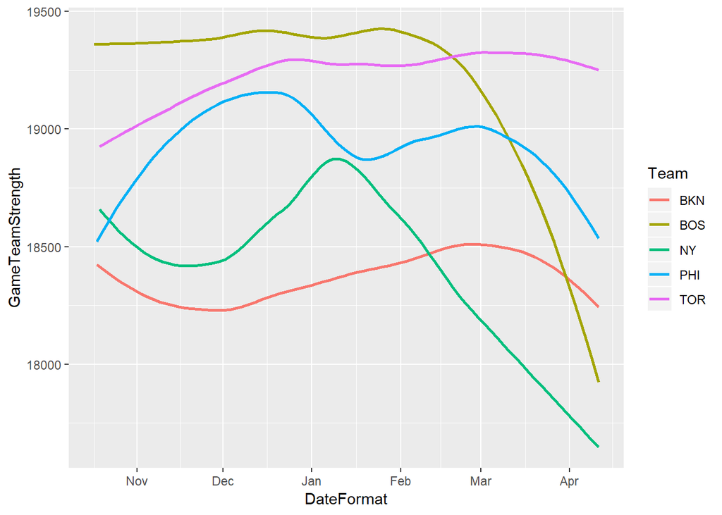

## Eastern Conference: Central Division

- Chicago Bulls - They were 6.5GB of 8th and 16-27 in mid January. Following this, Zach Lavine became injured, the team traded away Nikola Mirotic on February 1, and eventually finished 16GB from 8th (overall 13th in the conference), 3 games ahead of last place. At the end of the season, veteran players like Robin Lopez and Kris Dunn played fewer minutes (based on looking at box scores from games)
- Cleveland Cavaliers
- Detroit Pistons
- Indiana Pacers
- Milwaukee Bucks

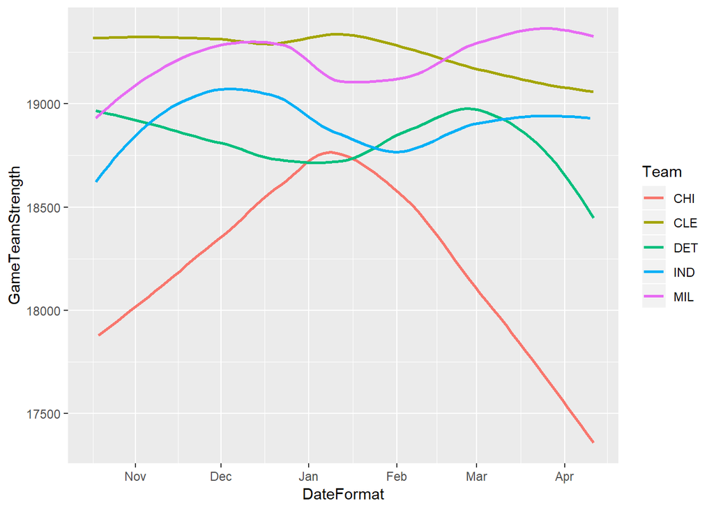

## Eastern Conference: Southeast Division

- Atlanta Hawks - They were 15-36 at the end of January, sitting in last place of the Eastern conference (10GB of 8th). The Hawks finished in last at 19GB (1 worse than the Orlando Magic). John Collins (a rookie player) moved into the team’s starting lineup by the end of the season and Dennis Schroder became injured.
- Charlotte Hornets
- Miami Heat
- Orlando Magic - At the end of February, the Magic had moved into last place of the Eastern Conference (18-43) going behind the Hawks (19-43). They finished the season 2nd to last 1GB ahead of the Hawks.
- Washington Wizards - Star player John Wall was sidelined for 2 months in the latter half of the season.

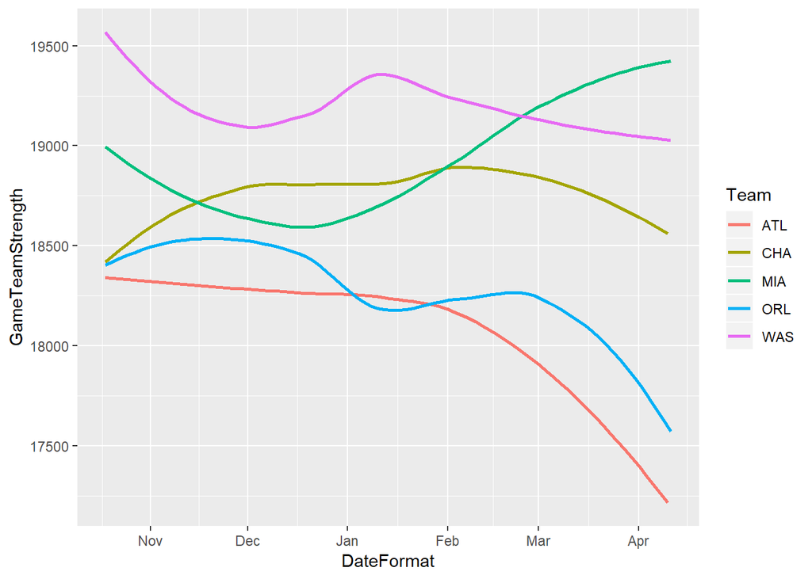

## Western Conference: Northwest Division

Denver Nuggets \ Minnesota Timberwolves \ Portland Trail Blazers \ Oklahoma City Thunder \ Utah Jazz \

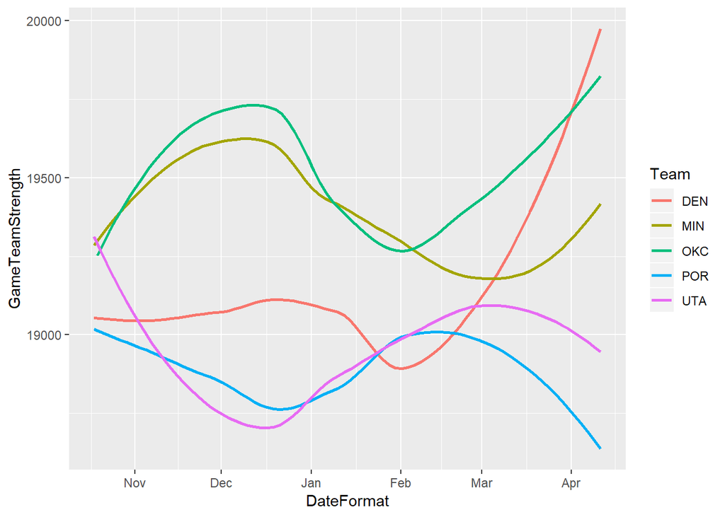

## Western Conference: Pacific Division

Golden State Warriors - As of February 1, they were 40-11 but then finished 18-13 in their remaining games. \ Los Angeles Clippers \ Los Angeles Lakers \ Phoenix Suns - The Suns were 18-41 and last in the Western Conference. They went 3-20 in the last 23 games. \ Sacramento Kings - The Kings moved into last place in the Western Conference at 18-43 and finished with a record of 27-55

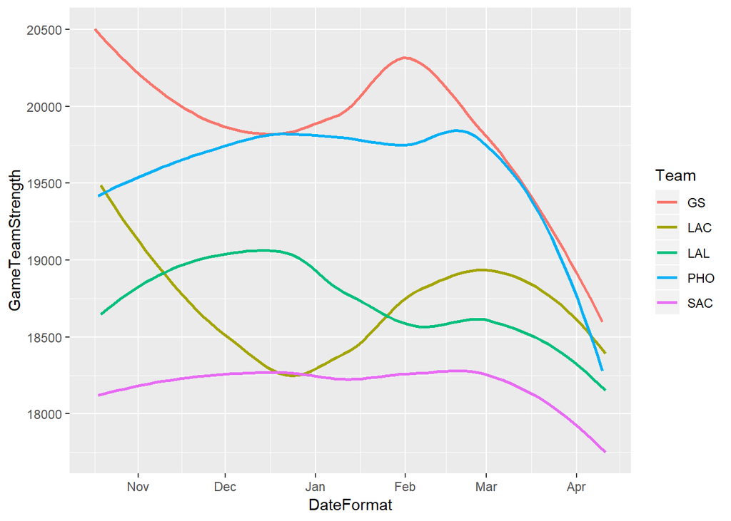

## Western Conference: Southwest Division

Dallas Mavericks - At the All Star Weekend, they were 18-40 (.5 GB) from last in the conference. Major player Dirk Nowitzki was injured at the end of the season. \ Houston Rockets \ Memphis Grizzlies - Star player Mike Conley was injured very early in the season. They went 4-28 to end the season (12.5GB from 8th to 25GB) and finished 2nd to last in the Western Conference. \ New Orleans Pelicans \ San Antonio Spurs \

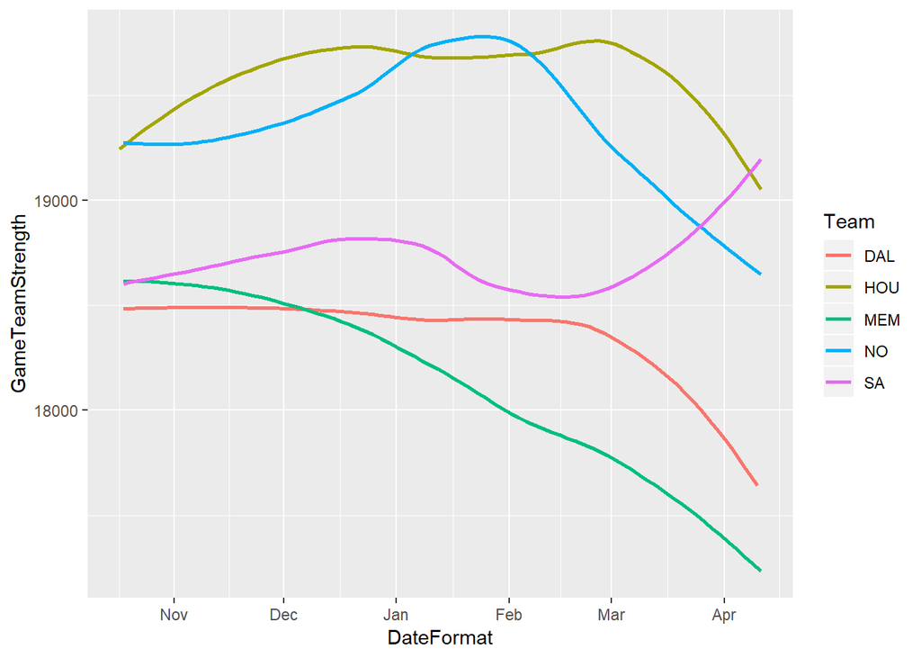

## Team Lineup Strength Overview

Based on the graphs presented above, we believe the majority of teams that have curves that decline significantly over the course of the season represent teams that could potentially be tanking since the curve decreasing means that they are playing their worse players more than their star players compared to what they usually did. In a tanking scenario, this decline should begin around February since that indicates the halfway point in the season. At this point, teams will know whether or not they have a legitimate chance of making the playoffs and can readjust their goals for the season.

There are some limitations to that analysis however. For some teams, it was not a deliberate attempt to lose but sometimes their star players got injured causing the curve to decline. For example, the Washington Wizards declined because of the injury to John Wall, the New York Knicks lost Kristaps Porzingis, and the Memphis Grizzlies lost Mike Conley. Additionally, teams like the Golden State Warriors choose to rest star players towards the end of the season once they have clinched a spot in the playoffs.

Sometimes the graphs went upwards unexpectedly because of trades midseason or free agent signings. Dwyane Wade was signed by the Miami Heat, the Pistons received Blake Griffin (trade) which caused their team strength value to increase.

However, by analyzing individual box scores from midseason to the end of the season, we can see that some other players may have gotten more minutes.

Based on the information of a declining lineup and poor standing, we believe that the following teams could potentially be tanking:

New York Knicks Chicago Bulls Orlando Magic Atlanta Hawks Dallas Mavericks Phoenix Suns Memphis Grizzlies